# A branching model of Covid-19 propagation

June 12, 2020

## Who we are: Public Services and Procurement Canada

### Centre for Operational Research and Data Science.

- We are the lead of PSPC's data science efforts.
- Come from the world of operational research—(many years with Department of National Defence).
- On loan from PSPC to help with Covid-19 modelling/statistical inference.
- Recently joined USC's serology efforts in Los Angeles for our hierarchical modelling expertise.
- Working with NORAD for work-force planning.
- All our code is available as an R package: branchsim.
- Also exists as a web-based app (under construction).

## Philosophy of George Box

### Journal of the American Statistical Association (1976)

- "All models are wrong, but some are useful."
- **Parsimony**
- "Since all models are wrong the scientist cannot obtain a "correct" one by excessive elaboration. On the contrary following William of Occam [s]he should seek an economical description of natural phenomena."
- **Worrying Selectively**
- "Since all models are wrong the scientist must be alert to what is importantly wrong. It is inappropriate to be concerned about mice when there are tigers abroad."

## Motivation

## SIR models and friends

- Compartmental models: work-horse framework for Covid-19 policy advice.
- Most policy advice derived from deterministic implementations.
- Readily coupled with economic models (behavioural pattern in \(R_0\), \(R_t\)).
- Highly flexible, but often difficult to calibrate/identifiability issues.
- Focus is on the large population limit.

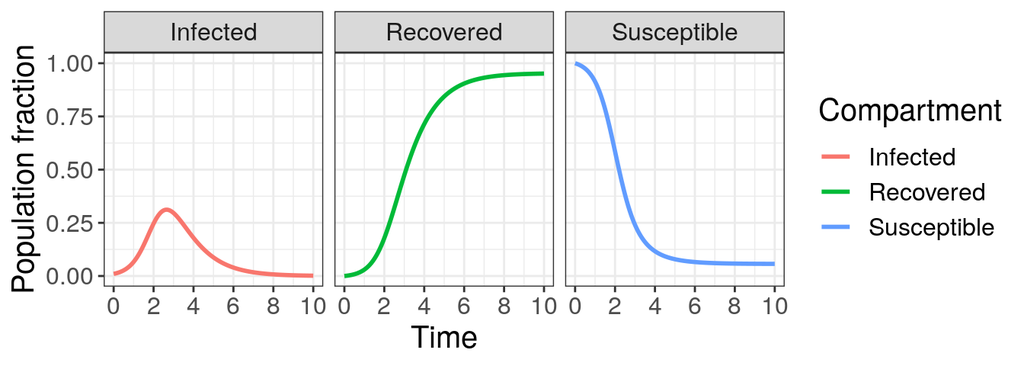

## Branching models

- Small population limit—stochastic nature highly relevant.
- Focus on different questions: extinction probabilities, time to Malthusian asymptotic growth, etc.
- Government of Canada back-to-work policy requires an understanding of small population limits (floor plans, team sizes, interaction rules).
- Useful in other government concerns (prisons, northern communities,…)

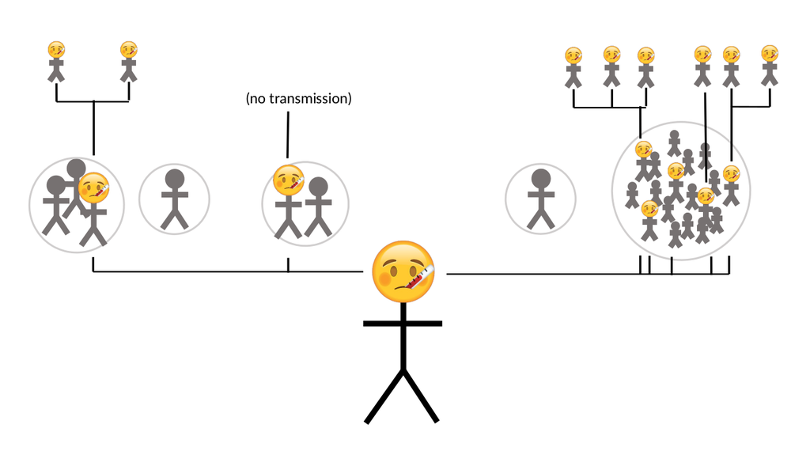

## Insipration

- Hellewell et al. Feasibility of controlling COVID-19 outbreaks by isolation of cases and contacts, The Lancet.
- Branching process model with serial interval distribution.
- Number of potential secondary cases produced by each individual is drawn from a negative binomial distribution with a mean equal to the reproduction number.
- Each potential new infection assigned a time of infection drawn from the serial interval distribution.
- Truncation of the process with an isolation event.
- In most of their scenarios contact tracing and case isolation is enough to control a new outbreak of COVID-19 within 3 months.

## Opportunities for model improvement

- Move to full continuous time—negative binomial process joined to a truncation process.
- A generative model offers generating/characteristic functions.
- Create parsimonious identifiable model with analytical understanding.
- Motivate the branching process (e.g., negative binomial counting) from distributional components.
- Inspired by inventory control problems in operational research.

## The model

## Crump-Mode-Jagers process

- CMJ described by a triple of random processes, not necessarily independent, \((\lambda_x, \xi_x(\cdot), \chi_x(\cdot))\) for individual \(x\), all iid copies.
- \(\lambda_x\) is a random variable that denotes an infected person's communicable period.
- \(\xi_x(t - \sigma_x)\) is the random number of infected people created by an infected person at every moment of her communicable period over the interval \([\sigma_x,t)\); \(\xi(t - \sigma_x) = 0\) if \(t - \sigma_x<0\). \(\mu(dt) = \mathbb{E}(\xi(dt)).\)
- \(\chi_x(t - \sigma_x)\) is a random characteristic of the infected person within the interval \([\sigma_x,t)\); \(\chi(t - \sigma_x) = 0\) if \(t - \sigma_x<0\). (E.g., \(\chi(t) = \mathbb{1}\{t\in [0,\lambda)\}\) is the number of infectious existing at moment \(t\)).

## Gamma negative binomial branching process

### Compound Poisson process with the log-series distribution

- \(Q(t) = \sum_{i=1}^{N(t)} \, Y_i\); \(N(t)\) the random number of events by \(t\) from the Poisson process (exponential waiting time between infectious events).
- \(\mathbb{P}(Y_i =k) = \frac{-1}{\ln(1-p)}\frac{p^k}{k}\); \(k \in \{1,2,3,\ldots\}\) (the number of people infected at an infectious event).
- \(\phi_{Q(t)}(u) =\mathbb{E}[e^{iuQ(t)}]= \left(\frac{1-p}{1-pe^{iu}}\right)^{rt}\); the characteristic function for the negative binomial process.
- \(Q(t) \sim \mathrm{NB}(rt,p)\); with \(\lambda = -r\ln(1-p)\).
- The negative binomial results from the underlying stochastic process.

## Gamma negative binomial branching process

- The negative binomial process is a Levy process.
- Subordinate the Levy process with a Gamma process: \(f_{T(t^\prime)}(x) = \frac{b^{at^\prime}}{\Gamma(at^\prime)} x^{a t^\prime-1}e^{-b x}\).
- The Gamma process truncates the infection process (communicable period): infection count process \(Z(t^\prime)\) has the characteristic function,
- \(\mathbb{E}[e^{iuZ(t^\prime)}] = \left(1- \frac{r}{b}\ln\left(\frac{1-p}{1-pe^{iu}}\right)\right)^{-at^\prime}\).
- Mean communicable period: \(at^\prime/b\)
- Branching model fully described.
- \(\mathbb{E}\left(\xi(dt)\right) = \frac{rp}{1-p} \left(1- \int_0^t\frac{b^{at^\prime}}{\Gamma(at^\prime)} x^{a t^\prime-1}e^{-b x}\, dx\right)\,dt\)
- Model parameters: \(\lambda\) (Poisson arrival rate), \(\mu\) (mean of log-series), \(a\), and \(b\) (Gamma parameters).

## Analytical control

- Extinction probabilities.
- Expectations over random characteristics (e.g., total infected, current infected population) and Malthusian parameters from renewal theory:
- \(m(t) = \mathbb{E}\left(\chi(t)\right) + \int_0^t m(t-u) \,\mathbb{E}\left(\xi(du)\right)\).
- Mean total number infected **given extinction** from random graphs with arbitrary vertex degree distributions [(Newman, Strogatz, and Watts cond-mat/0007235)](https://arxiv.org/abs/cond-mat/0007235)

.

## Simulation

## The infected compartment

### Probability of extinction

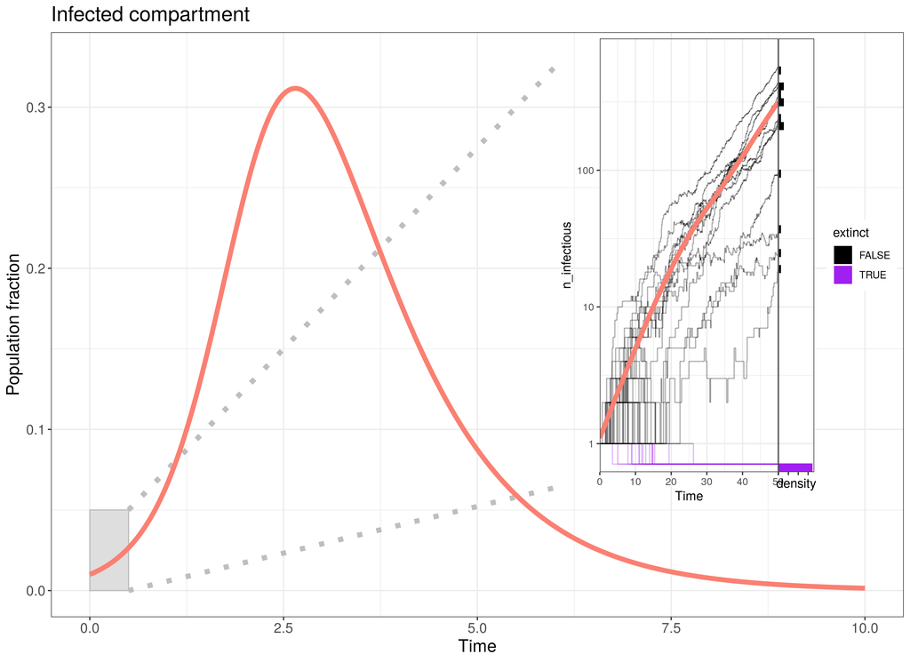

## Branching process extinction probability

- \(G(t;s) = \mathbb{E}\left[s^{Z(t)}\left|\right.Z(0)=1\right]\)
- \(\xi(t) = \#\{\delta_i: \delta_i \leq t\} = \sum_{i=1}^\infty \mathbb{1} \{\delta_i \leq t\}.\)
- \(q= \mathbb{P}\left(\lim_{t\to\infty} Z(t) =0\right) = \lim_{t\to\infty} G(t;0)\)
- \(q = \lim_{t\to\infty} \mathbb{E}\left[ \prod_{i=1}^{\xi(t)}G(t - \delta_i;0)\right]= \mathbb{E}\left[q^N \right]\)
- For our process: \[q = \left(1- \frac{r}{b}\ln\left(\frac{1-p}{1-pq}\right)\right)^{-at^\prime}\]

## Extinction probabilities

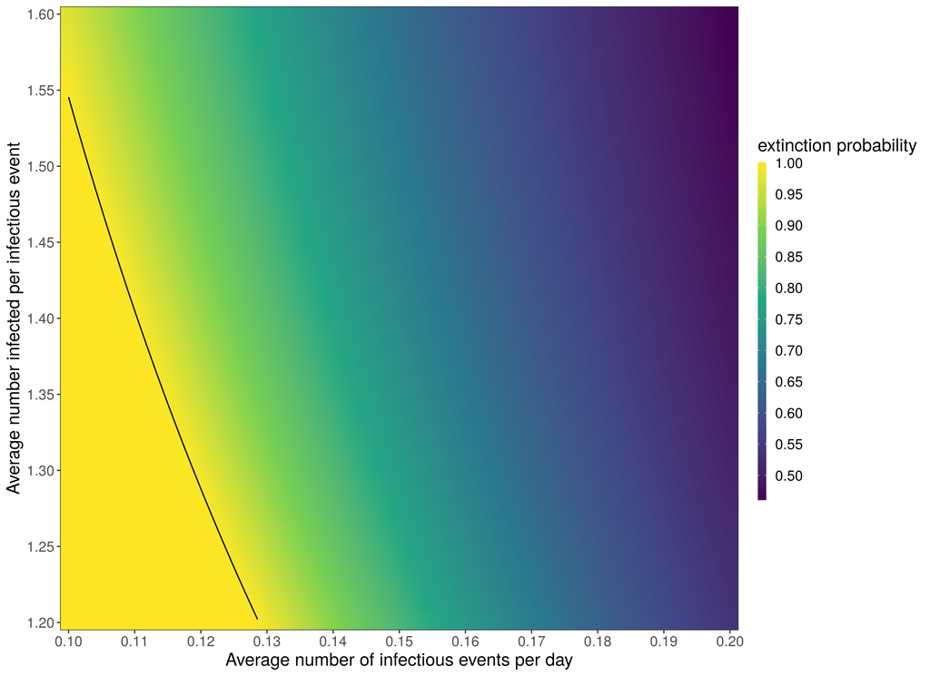

## Graph analysis

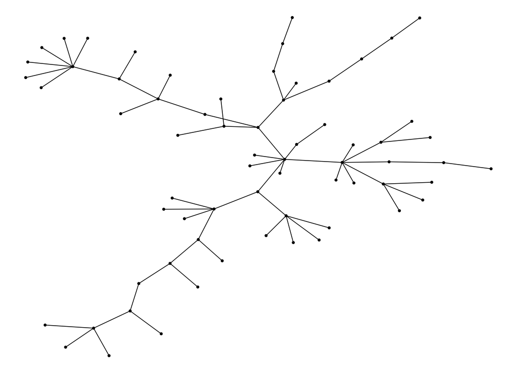

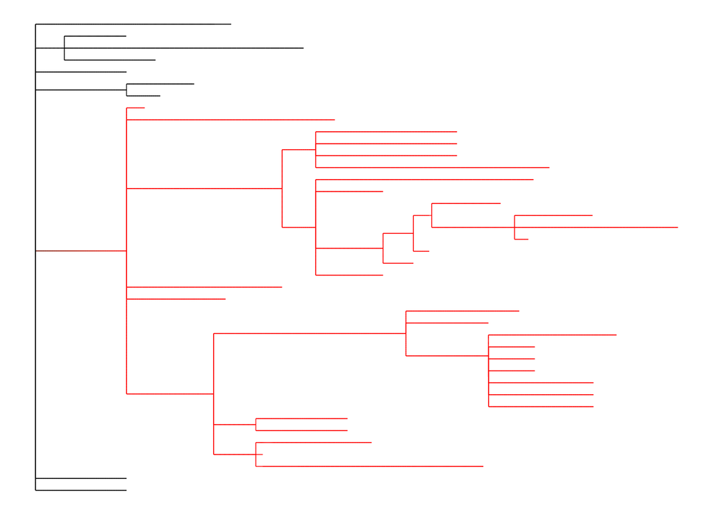

- Graph component size: out-going vertex distribution is our branching process.
- Compute average size given extinction: graph size distribution excluding the giant component (if exists).
- Consistent with the renewal equation before phase transition.

## Graph analysis: component size

- Average size of graph, \(\bar s\), given extinction [(Newman, Strogatz, and Watts cond-mat/0007235)](https://arxiv.org/abs/cond-mat/0007235).
- Extinction a.s. (renewal theory matches) \[\bar s = \frac{1}{1 - G^\prime(1)}\]
- Malthusian parameter > 0; extinction probability \(q\) \[\bar s = 1 + \frac{zq}{1 - G^\prime(q)}\]
- \(z = \frac{1 - q}{\int_u^1 G(s)\,ds}\)

## Simulation analysis

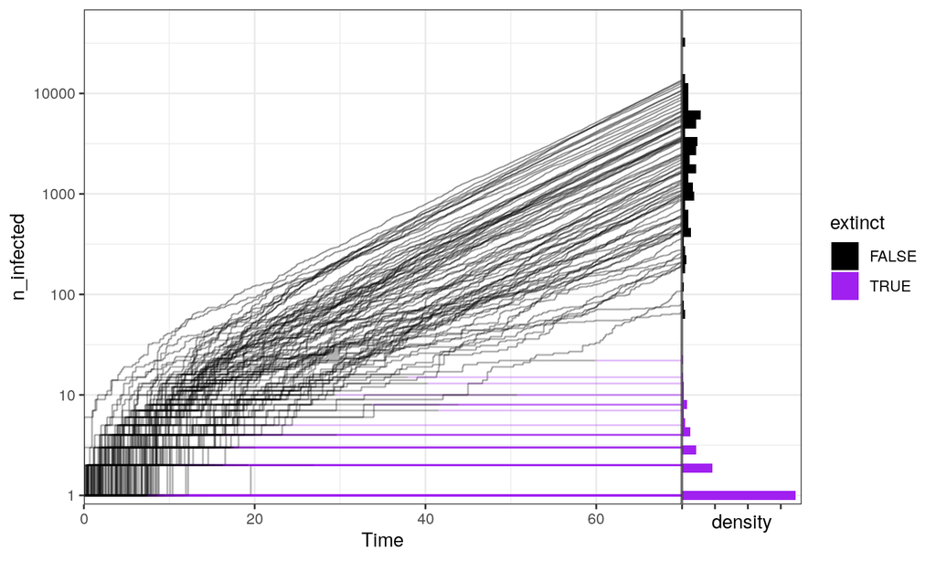

## Simulation analysis

- Build sample paths to examine best/wort cases.
- Graphically observe the onset of the compartmental model limit.
- See the distribution of extinct populations.
- Sensitivity analysis around model parameters and the communicable period.

## Simulation with intervention

- Contact tracing and isolation: switch from communicable period distribution \(x_0\) to a new commumicable period distribution \(x_1\) with probability \(p\).
- \(U_x(t) = \prod_{j =0}^1[Z_j(t)]^{\mathbb{1}\{y = j\}}\); \(y\sim\text{Bin}(1,p)\)
- \(\mathbb{E}(U_x(t)) = (1-p)\,\mathbb{E}(Z_0(t)) + p\,\mathbb{E}(Z_1(t))\): sensitivity/iso-contour analysis.
- Simulate the effect of the intervention—changes to extinction probabilities.
- Working with PSPC Real Property division for back-to-work policy guidance.

## Simulation with intervention

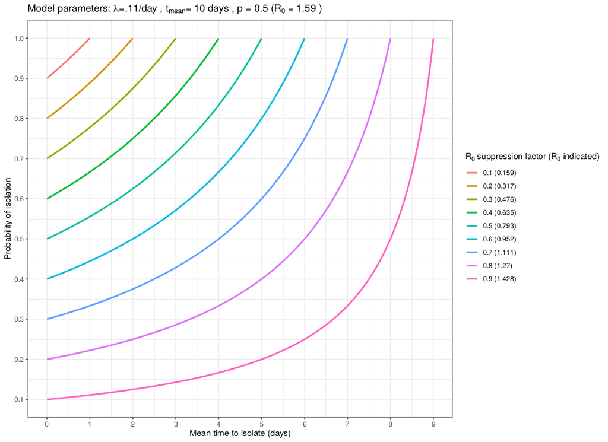

## Estimation

## A complete history of an outbreak

- We define a complete history of an outbreak as a set of \(N\) observations taking the form of a 6-tuple:
- \((i,j,b_{i},d_{i},m_{i},o_{i})\)
- \[\begin{align} i &\phantom{=} \text{index of individual}\\ j &\phantom{=} \text{index of parent}\\ b_{i} &\phantom{=} \text{time of birth}\\ d_{i} &\phantom{=} \text{time of death}\\ m_{i} &\phantom{=} \text{number of offspring birth events}\\ o_{i} &\phantom{=} \text{number of offspring} \end{align}\]

## Parameter inference from a complete history

- With the following summary statistics:
- \[\begin{align} L & = \sum_{i} d_{i} - b_{i} & \lambda & = \prod_{i} (d_{i} - b_{i})\\ M & = \sum_{i} m_{i} & O & = \sum_{i} o_{i} \nonumber \end{align}\]
- resample the GNBBP parameters as follows:
- \[\begin{align} p\,|\,r,L,O &\sim \text{Beta}\left(a_{0} + O,b_{0} + r L\right)\\ r\,|\,p,L,M &\sim \text{Gamma}\left(\eta_{0}+M,\rho_{0}-L\ln(1-p)\right)\\ \beta\,|\,\alpha,L,N &\sim \text{Gamma}\left(\gamma_{0}+\alpha N,\delta_{0}+L\right)\\ \alpha\,|\,\beta,\Lambda,N &\sim \text{GammaShape}\left(\epsilon_{0}\Lambda,\zeta_{0}+N,\theta_{0}+N\right) \end{align}\]

## Dealing with noisy observations

- While an outbreak is in progress, we will not have complete observations:
- The variables \(d_{i}\), \(m_{i}\), \(o_{i}\) will be right-censored for many individuals.
- We may not fully know the mapping of offspring to parents.
- Our observations of birth times \(b_{i}\) may be noisy.
- We might not observe some individuals at all, etc, etc.
- In these cases, we use a **forward filtering backwards sampling** approach.
- With \((\alpha,\beta,r,p)\) and our observed data fixed, generate a synthetic complete history consistent with observed data.
- Using synthetic complete history, resample \((\alpha,\beta,r,p)\).

## Example: Augmentation of censored observations

- While an outbreak is in progress, many individuals will be censored at the end of our observation window \(C\). We augment these to complete records as follows:
- Generate synthetic time of death \(d_{i}'\) by sampling off of the tail of the gamma distribution; i.e., drawing from the gamma conditioned on surviving at least \(C-b_{i}\)
- \[\begin{align} z & \sim \text{GammaTail}(\alpha,\beta,C-b_{i}) \nonumber \\ d_{i}' & = b_{i} + z \nonumber \end{align}\]

## Example: Augmentation of censored observations

- Draw additional arrivals:
- \[m' \sim \text{Poisson}(-r (d_{i}-T)\log(1-p))\]
- Draw additional offspring at each arrival \(k=1,\ldots,m'\)
- \[o_{k}' \sim \text{Logarithmic}(p)\]

## Example: Working from birth times only

- Assume we only observe the set of birth times \(\left\{b_{i}\right\}\).
- For a given individual \(i\) (or birth time, if multiple coincidental arrivals), randomly assign a parent \(j<i\) using weights.
- \[w_{j} = \frac{\Gamma(\alpha,\beta (b_{i}-b_{j}))}{\Gamma(\alpha)}\]
- Assign death times to individuals, conditioned on last birth of assigned offspring as appropriate.
- Complete the history by generating additional offspring for those individuals with \(d_{i}\) after the censoring time as per previous slide.

## Summary

## Summary

- An extension of Hellewell et al. that results in a complete generative process.
- Generating/characteristic function gives us analytic control.
- Distributions permit estimation through Markov Chain Monte Carlo methods, particle filters, etc.
- Can examine contact tracing and other propagation interruption scenarios.
- Help set policy in small populations (back-to-work, headquarter floor plans, prisons, borders, etc.)